# Global vs vegetation-specific s2biophys

Compare **FAPAR and effective leaf area index (LAIe)** retrieval maps for three small regions. Both models use the same Sentinel-2 observations, cloud mask, 20 m grid and temporal aggregation (predict each observation, then average). The global ensemble has five members; each independently optimized vegetation-specific ensemble has three.

The selected variant is applied to **every valid pixel in the region**, with no vegetation-class mask. These are model comparisons, not accuracy assessments against ground truth.

Run from this repository with `gee-biophys`, `matplotlib` and a Jupyter kernel installed. Authenticate once with `earthengine authenticate`; optionally set `EE_PROJECT` below. Downloads use xee and predictions run locally.

Setup and processing cells are collapsed; expand them to inspect or modify the workflow. Maps and summary tables remain visible.

## Regions

The current configs use 5 km × 5 km squares in local UTM. They represent the requested vegetation settings but can contain mixed cover:

| Region | Variant | Period | Context |
| --- | --- | --- | --- |
| Lägeren, Switzerland | `temperate_broadleaf_forest` | June 2024 | Beech-dominated forest ([WSL](https://lwf.wsl.ch/en/flaechen/laegeren/)) |
| Saguaro west, Arizona | `arid_shrubland` | August–September 2024 | Low-elevation Sonoran desert scrub ([USGS](https://www.usgs.gov/geology-and-ecology-of-national-parks/ecology-saguaro-national-park)) |
| Konza Prairie, Kansas | `temperate_nonforest` | Mid Mai–Mid June 2024 | Tallgrass prairie / agriculture ([NEON](https://www.neonscience.org/field-sites/konz)) |

The extents and dates come directly from the three tested example configs.

## Sentinel-2 RGB and side-by-side retrievals

The first column is a true-colour **B4/B3/B2 median composite** of the same cloud-masked observations used for prediction. RGB uses a fixed 0–0.30 reflectance stretch and gamma 1.2 and a saturation factor of 1.5 across all regions. Gray RGB pixels have no valid observations.

All three columns share map bounds; the two retrieval columns share a color scale. Axes show distance in the local projected grid; north is up. Gray retrieval pixels have no paired valid retrieval. FAPAR/FCOVER are fractions; LAIe is m²/m².

### FAPAR

Fraction of absorbed photosynthetically active radiation; both models use the same 0–1 scale.

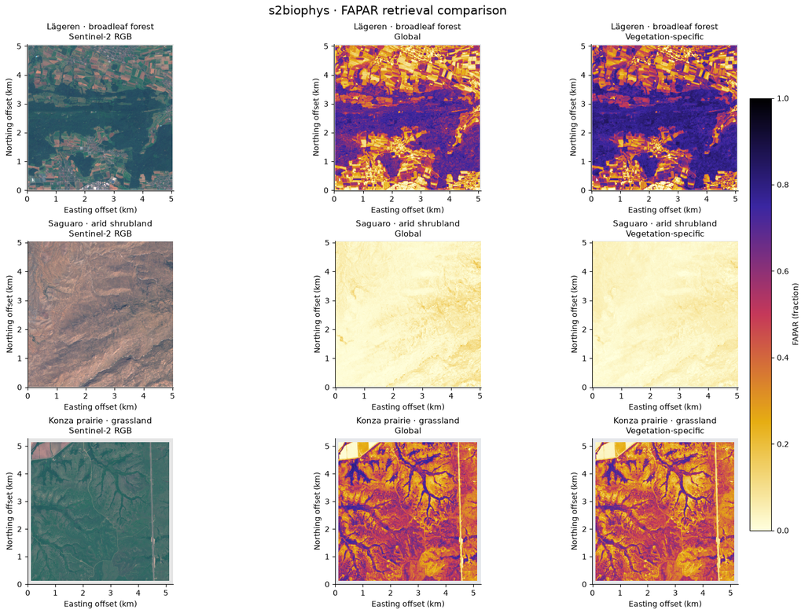

### LAIe

Effective leaf area index (m²/m²); both models use the same 0–5 scale and the same input observations as FAPAR.

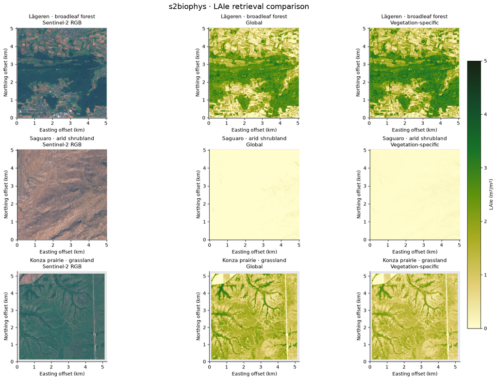

### Numerical comparison

Differences are vegetation-specific minus global, computed over paired valid pixels separately for each trait.

|  | trait | region | variant | paired pixels | global mean | specific mean | mean difference (specific − global) | mean absolute difference |
| --- | --- | --- | --- | --- | --- | --- | --- | --- |
| 0 | FAPAR | Lägeren · broadleaf forest | temperate_broadleaf_forest | 62991 | 0.4872 | 0.5924 | 0.1052 | 0.1054 |
| 1 | FAPAR | Saguaro · arid shrubland | arid_shrubland | 63001 | 0.0377 | 0.0347 | -0.0030 | 0.0081 |
| 2 | FAPAR | Konza prairie · grassland | temperate_nonforest | 63001 | 0.4535 | 0.4115 | -0.0420 | 0.0426 |
| 3 | LAIe | Lägeren · broadleaf forest | temperate_broadleaf_forest | 62991 | 1.7243 | 2.0045 | 0.2802 | 0.2802 |
| 4 | LAIe | Saguaro · arid shrubland | arid_shrubland | 63001 | 0.0182 | 0.0487 | 0.0305 | 0.0319 |
| 5 | LAIe | Konza prairie · grassland | temperate_nonforest | 63001 | 1.3502 | 1.1504 | -0.1998 | 0.2000 |

Interpret differences as sensitivity to model choice. They do not establish which model is more accurate. Both models receive the same local input data; no water or vegetation-class mask is added here. The comparison uses mean retrievals; variant uncertainty currently inherits the global recalibration table.

## Appendix

Tables from Manuscript:

Felix Specker, Anna K. Schweiger, Jean-Baptiste Féret et al. Advancing Ecosystem Monitoring with Global High-Resolution Maps of Vegetation Biophysical Properties, 23 April 2026, PREPRINT (Version 2) available at Research Square [https://doi.org/10.21203/rs.3.rs-6343364/v2]

- Table S5: Biome–land-cover specific recoding.
- Table S6: Performance of biome3land-cover-specific and generic models.

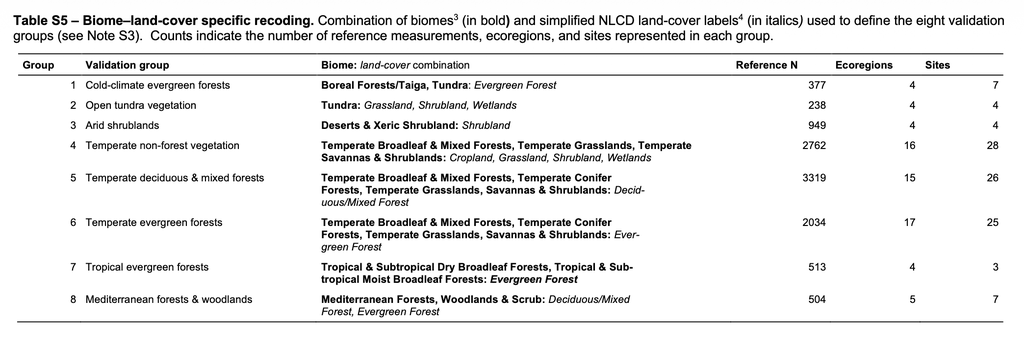

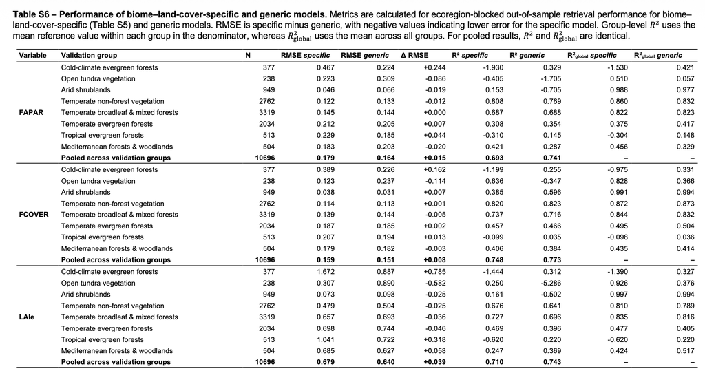